# Estimating Effect of Tax Incentives on Donations Considering Self-Selection of Tax Incentives in South Korea

Results of FE-2SLS

Hiroki Kato

Tsuyoshi Goto

Yongrok Kim

2022-07-11

ベースラインで示した固定効果モデルには2つの内生性が存在する。

1. 寄付価格が個人の寄付行動によって決まる
2. 寄付控除の申告が自己選択であること

これに対処するために、二段階固定効果モデル（FE-2SLS）を推定する。 操作変数は(1)applicable first-unit priceと(2)給与所得者ダミーである。

- first-unit priceは寄付額ゼロのときの寄付価格であり、寄付額とは独立に決まる。 また、寄付価格が低いほど、寄付による節税の便益が大きいので、 この変数は申告による便益を捉えている。
- 給与所得者は、自営業者と比較して、簡単に寄付控除を申告出来るので、 給与所得者ダミーは寄付控除の申告コストの代理変数となる。

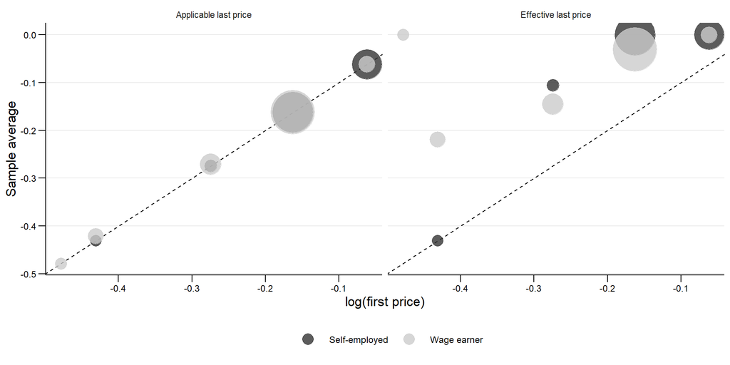

Figure 1: Relationship between Applicable First Price and Last Price by Employment Status. Note: The bubble size indicates sample size. Due to the small sample size, the leftmost bubbles for salaried and self-employed workers are less informative ($N=6$ for wage earner and $N=2$ for self-employed).

操作変数に関する我々の予測が成立していることをデータから確認する。

Table 1: Tax-Price Elasticity Estimated by FE-2SLS

Intensive-margin

Extensive-margin

log(Effective last price)

－1.879***

－1.699**

－1.872***

－1.469***

－1.046***

－1.433***

(0.602)

(0.730)

(0.602)

(0.150)

(0.207)

(0.150)

log(income)

0.726

0.855

0.731

1.761***

1.967***

1.779***

(1.506)

(1.536)

(1.506)

(0.285)

(0.311)

(0.286)

Implied price elasticity

-6.071

-4.322

-5.921

(0.621)

(0.857)

(0.620)

Num.Obs.

6247

6247

6247

24984

24982

24982

Instruments

(A)+(B)

(A)+(B)

F-statistics of instruments

1028.00

698.82

514.26

2619.68

1396.10

1319.61

Wu-Hausman test, p-value

0.001

0.019

0.001

0.000

0.000

0.000

Notes: $^{*}$ $p &lt; 0.1$, $^{**}$ $p &lt; 0.05$, $^{***}$ $p &lt; 0.01$. Standard errors are clustered at household level. Instruments are (A) logged value of the applicable first price, and (B) the product of wage earner dummy and logged value of the applicable first price. We control squared age (divided by 100), number of household members, a dummy that indicates having dependents, a set of dummies of industry, a set of dummies of residential area, and individual and time fixed effects.

表1はFE-2SLSの第二段階の推定結果を示している。

- 操作変数は(1)first applicable price、(2)first applicable priceと 給与所得者ダミーの積、(3) (1)と(2)の両方を用いる。
- 寄付者に限定すると、寄付額に対するeffective last priceの価格弾力性は -1.9から-1.7の範囲で得られた。 これは通常の固定効果モデルの価格弾力性よりも3倍弾力的であり、 Wu-Hausman検定より統計的に有意な差である。 また、F値が500以上あるので、この結果の差は操作変数の弱相関による問題ではない。
- 寄付行動をアウトカムとするとき、effective last priceの係数は-1.5から-1の範囲で得られた。 価格弾力性に変換するために、この係数を寄付者比率で割ると、 価格弾力性は-6.25から-4.17の範囲となる。 これは通常の固定効果モデルの価格弾力性の半分以下とであり、 Wu-Hausman検定より統計的に有意な差である。 また、F値が1000以上あるので、この結果の差は操作変数の弱相関による問題ではない。